# Alcohol Sales Prediction

#### Importing the necessary libraries.

```python
import numpy as np
import pandas as pd
import matplotlib.pyplot as plt
import seaborn as sns
%matplotlib inline

import plotly.express as px
import plotly as py
import plotly.graph_objs as go
from plotly.offline import init_notebook_mode, iplot

from statsmodels.tsa.seasonal import seasonal_decompose
from statsmodels.graphics.tsaplots import plot_acf
from statsmodels.tsa.arima_model import ARIMA
from progressbar import *

from sklearn.preprocessing import LabelEncoder

from math import sqrt

# Function for splitting training and test set
from sklearn.model_selection import train_test_split

# Function to perform data standardization
from sklearn.preprocessing import StandardScaler

# Import classes for ML Models
from sklearn.linear_model import Ridge  ## Linear Regression + L2 regularization
from sklearn.ensemble import RandomForestRegressor
from xgboost import XGBRegressor

# Evaluation Metrics
from sklearn.metrics import mean_squared_error as mse
from sklearn.metrics import r2_score
from sklearn.metrics import mean_absolute_error as mae

# To save the final model on disk
from sklearn.externals import joblib

from keras.models import Sequential, Model
from keras import optimizers
from keras.layers import Dense

import warnings
warnings.filterwarnings("ignore")
```

## Exploratory Data Analysis

#### Reading CSV file data.

Since we want to work with only subset of data we will take only first 20K rows.

```python
df = pd.read_csv("4609_1138586_bundle_archive/Iowa_Liquor_Sales.csv", nrows = 20000)
```

Displaying first 5 rows.

```python
df.head()
```

|  | Invoice/Item Number | Date | Store Number | Store Name | Address | City | Zip Code | Store Location | County Number | County | ... | Item Number | Item Description | Pack | Bottle Volume (ml) | State Bottle Cost | State Bottle Retail | Bottles Sold | Sale (Dollars) | Volume Sold (Liters) | Volume Sold (Gallons) |
| --- | --- | --- | --- | --- | --- | --- | --- | --- | --- | --- | --- | --- | --- | --- | --- | --- | --- | --- | --- | --- | --- |
| 0 | S29198800001 | 11/20/2015 | 2191 | Keokuk Spirits | 1013 MAIN | KEOKUK | 52632 | 1013 MAIN\nKEOKUK 52632\n(40.39978, -91.387531) | 56.0 | Lee | ... | 297 | Templeton Rye w/Flask | 6 | 750 | $18.09 | $27.14 | 6 | $162.84 | 4.50 | 1.19 |
| 1 | S29195400002 | 11/21/2015 | 2205 | Ding's Honk And Holler | 900 E WASHINGTON | CLARINDA | 51632 | 900 E WASHINGTON\nCLARINDA 51632\n(40.739238, ... | 73.0 | Page | ... | 297 | Templeton Rye w/Flask | 6 | 750 | $18.09 | $27.14 | 12 | $325.68 | 9.00 | 2.38 |
| 2 | S29050300001 | 11/16/2015 | 3549 | Quicker Liquor Store | 1414 48TH ST | FORT MADISON | 52627 | 1414 48TH ST\nFORT MADISON 52627\n(40.624226, ... | 56.0 | Lee | ... | 249 | Disaronno Amaretto Cavalli Mignon 3-50ml Pack | 20 | 150 | $6.40 | $9.60 | 2 | $19.20 | 0.30 | 0.08 |
| 3 | S28867700001 | 11/04/2015 | 2513 | Hy-Vee Food Store #2 / Iowa City | 812 S 1ST AVE | IOWA CITY | 52240 | 812 S 1ST AVE\nIOWA CITY 52240\n | 52.0 | Johnson | ... | 237 | Knob Creek w/ Crystal Decanter | 3 | 1750 | $35.55 | $53.34 | 3 | $160.02 | 5.25 | 1.39 |
| 4 | S29050800001 | 11/17/2015 | 3942 | Twin Town Liquor | 104 HIGHWAY 30 WEST | TOLEDO | 52342 | 104 HIGHWAY 30 WEST\nTOLEDO 52342\n(41.985887,... | 86.0 | Tama | ... | 249 | Disaronno Amaretto Cavalli Mignon 3-50ml Pack | 20 | 150 | $6.40 | $9.60 | 2 | $19.20 | 0.30 | 0.08 |

5 rows × 24 columns

```python
# Last 5 rows
df.tail()
```

|  | Invoice/Item Number | Date | Store Number | Store Name | Address | City | Zip Code | Store Location | County Number | County | ... | Item Number | Item Description | Pack | Bottle Volume (ml) | State Bottle Cost | State Bottle Retail | Bottles Sold | Sale (Dollars) | Volume Sold (Liters) | Volume Sold (Gallons) |
| --- | --- | --- | --- | --- | --- | --- | --- | --- | --- | --- | --- | --- | --- | --- | --- | --- | --- | --- | --- | --- | --- |
| 19995 | S05176600062 | 04/23/2012 | 2621 | Hy-Vee Food Store #3 / Sioux City | 3301 GORDON DR | SIOUX CITY | 51105 | 3301 GORDON DR\nSIOUX CITY 51105\n(42.487752, ... | 97.0 | Woodbury | ... | 87408 | Jose Cuervo Especial Silver | 12 | 750 | $10.11 | $15.35 | 2 | $30.70 | 1.50 | 0.40 |
| 19996 | S08779200046 | 11/06/2012 | 2522 | Hy-Vee Wine and Spirits / Spirit Lak | HWY 9 & 71 | SPIRIT LAKE | 51360 | HWY 9 &amp; 71\nSPIRIT LAKE 51360\n | 30.0 | Dickinson | ... | 80576 | Arrow Peppermint Schnapps | 12 | 750 | $3.97 | $5.95 | 3 | $17.85 | 2.25 | 0.59 |
| 19997 | S27323000036 | 08/13/2015 | 4829 | Central City 2 | 1501 MICHIGAN AVE | DES MOINES | 50314 | 1501 MICHIGAN AVE\nDES MOINES 50314\n(41.60556... | 77.0 | Polk | ... | 34457 | Ketel One Imported Vodka | 12 | 1000 | $17.50 | $26.25 | 72 | $1890.00 | 72.00 | 19.02 |
| 19998 | S17055900115 | 01/27/2014 | 2521 | Hy-Vee Food and Drug / Grand / WDM | 1990 GRAND AVENUE | WEST DES MOINES | 50265 | 1990 GRAND AVENUE\nWEST DES MOINES 50265\n(41.... | 77.0 | Polk | ... | 28206 | Bombay Dry Gin | 12 | 750 | $10.26 | $15.39 | 4 | $61.56 | 3.00 | 0.79 |
| 19999 | S23916000021 | 02/09/2015 | 3549 | Quicker Liquor Store | 1414 48TH ST | FORT MADISON | 52627 | 1414 48TH ST\nFORT MADISON 52627\n(40.624226, ... | 56.0 | Lee | ... | 77674 | Smirnoff Green Apple | 12 | 750 | $8.25 | $12.38 | 2 | $24.76 | 1.50 | 0.40 |

5 rows × 24 columns

Printing the shape of the data.

```python
df.shape
```

```
(20000, 24)
```

We have around 20000 rows and 24 columns in the dataset.

#### Columns of the dataset

```python
df.columns
```

```
Index(['Invoice/Item Number', 'Date', 'Store Number', 'Store Name', 'Address',
       'City', 'Zip Code', 'Store Location', 'County Number', 'County',
       'Category', 'Category Name', 'Vendor Number', 'Vendor Name',
       'Item Number', 'Item Description', 'Pack', 'Bottle Volume (ml)',
       'State Bottle Cost', 'State Bottle Retail', 'Bottles Sold',
       'Sale (Dollars)', 'Volume Sold (Liters)', 'Volume Sold (Gallons)'],
      dtype='object')
```

```python
# Checknig the types of columns
df.dtypes
```

```
Invoice/Item Number       object
Date                      object
Store Number               int64
Store Name                object
Address                   object
City                      object
Zip Code                  object
Store Location            object
County Number            float64
County                    object
Category                 float64
Category Name             object
Vendor Number              int64
Vendor Name               object
Item Number                int64
Item Description          object
Pack                       int64
Bottle Volume (ml)         int64
State Bottle Cost         object
State Bottle Retail       object
Bottles Sold               int64
Sale (Dollars)            object
Volume Sold (Liters)     float64
Volume Sold (Gallons)    float64
dtype: object
```

```python
df.info()
```

```
<class 'pandas.core.frame.DataFrame'>
RangeIndex: 20000 entries, 0 to 19999
Data columns (total 24 columns):
Invoice/Item Number      20000 non-null object
Date                     20000 non-null object
Store Number             20000 non-null int64
Store Name               20000 non-null object
Address                  20000 non-null object
City                     20000 non-null object
Zip Code                 20000 non-null object
Store Location           20000 non-null object
County Number            19967 non-null float64
County                   19967 non-null object
Category                 19915 non-null float64
Category Name            19910 non-null object
Vendor Number            20000 non-null int64
Vendor Name              20000 non-null object
Item Number              20000 non-null int64
Item Description         20000 non-null object
Pack                     20000 non-null int64
Bottle Volume (ml)       20000 non-null int64
State Bottle Cost        20000 non-null object
State Bottle Retail      20000 non-null object
Bottles Sold             20000 non-null int64
Sale (Dollars)           20000 non-null object
Volume Sold (Liters)     20000 non-null float64
Volume Sold (Gallons)    20000 non-null float64
dtypes: float64(4), int64(6), object(14)
memory usage: 3.7+ MB
```

```python
# Displaying unique names of country
print(df['City'].nunique())
df['City'].unique()
```

```
367
```

```
array(['KEOKUK', 'CLARINDA', 'FORT MADISON', 'IOWA CITY', 'TOLEDO',
       'HOLSTEIN', 'WATERLOO', 'MUSCATINE', 'DUNLAP', 'SHELDON',
       'DES MOINES', 'ATLANTIC', 'CLINTON', 'DUBUQUE', 'CEDAR FALLS',
       'DENISON', 'ONAWA', 'WAUKEE', 'LE CLAIRE', 'PELLA', 'ALTOONA',
       'MOUNT PLEASANT', 'OSKALOOSA', 'BANCROFT', 'HARLAN', 'ANKENY',
       'IOWA FALLS', 'WAVERLY', 'CEDAR RAPIDS', 'SIOUX CITY', 'NEWTON',
       'MARSHALLTOWN', 'SHENANDOAH', 'MOUNT AYR', 'COUNCIL BLUFFS',
       'WASHINGTON', 'DAVENPORT', 'KNOXVILLE', 'FORT DODGE',
       'INDEPENDENCE', 'MISSOURI VALLEY', 'CRESCO', 'WEST DES MOINES',
       'ESTHERVILLE', 'COON RAPIDS', 'AMES', 'PLEASANT HILL',
       'MASON CITY', 'RED OAK', 'SPENCER', 'BURLINGTON', 'GUTHRIE CENTER',
       'ANAMOSA', 'CHARITON', 'SPIRIT LAKE', 'BETTENDORF', 'MILFORD',
       'DECORAH', 'GRIMES', 'PARKERSBURG', 'NEVADA', 'EAGLE GROVE',
       'LECLAIRE', 'CLEAR LAKE', 'ARNOLDS PARK', 'WILTON', 'JOHNSTON',
       'TIPTON', 'NORTH LIBERTY', 'MAPLETON', 'SIBLEY', 'LAKE MILLS',
       'PALO', 'CONRAD', 'WAPELLO', 'TRIPOLI', 'LE MARS', 'MT VERNON',
       'SIOUX CENTER', 'ALGONA', 'EMMETSBURG', 'BELLEVUE', 'WEST POINT',
       'STORM LAKE', 'CHARLES CITY', 'MARENGO', 'NORA SPRINGS',
       'DAKOTA CITY', 'MOUNT VERNON', 'MONTICELLO', 'COLFAX', 'CRESTON',
       'IDA GROVE', 'MONONA', 'HUMBOLDT', 'NORWALK', 'SUMNER',
       'EVANSDALE', 'JEFFERSON', 'GUTTENBERG', 'GOWRIE', 'URBANDALE',
       'SWISHER', 'OTTUMWA', 'GRAND MOUND', 'WEST LIBERTY', 'OTTUWMA',
       'NORTH ENGLISH', 'CORALVILLE', 'LARCHWOOD', 'FOREST CITY', 'CLIVE',
       'SAC CITY', 'MAQUOKETA', 'WINTERSET', 'DYERSVILLE',
       'WINDSOR HEIGHTS', 'ORANGE CITY', 'GRAETTINGER', 'CLARKSVILLE',
       'BEDFORD', 'WEST BURLINGTON', 'CAMANCHE', 'ROCKWELL CITY', 'BRITT',
       'DURANT', 'CARROLL', 'SOLON', 'MARION', 'ALLISON', 'MANCHESTER',
       'PANORA', 'OELWEIN', 'NASHUA', 'FAIRFIELD', 'SHELLSBURG',
       'INDIANOLA', 'BROOKLYN', 'SCRANTON', 'CHEROKEE', 'VINTON',
       'HAMPTON', 'FORT ATKINSON', 'NEW HAMPTON', 'EDDYVILLE',
       'CENTRAL CITY', 'TRAER', 'OSCEOLA', 'WEBSTER CITY', 'DENVER',
       'ELLSWORTH', 'WESLEY', 'ROCKWELL', 'ELKADER', 'PLEASANTVILLE',
       'CASCADE', 'SIGOURNEY', 'PRINCETON', 'AUDUBON', 'DYSART', 'PERRY',
       'SIOUX RAPIDS', 'ELDRIDGE', 'MEDIAPOLIS', 'COLUMBUS JUNCTION',
       'STORY CITY', 'WELLMAN', 'HAWARDEN', 'BOONE', 'ARLINGTON',
       'WAUKON', 'LEMARS', 'ADEL', 'TREYNOR', 'CARTER LAKE', 'ELDORA',
       'GRINNELL', 'MARCUS', 'LANSING', 'AVOCA', 'ALTA', 'CLARION',
       'DAYTON', 'OSAGE', 'STATE CENTER', 'CARLISLE', 'SWEA CITY',
       'BELLE PLAINE', 'WEST BRANCH', 'ACKLEY', 'ALDEN', 'GARNER',
       'BLUE GRASS', 'STRATFORD', 'BLOOMFIELD', 'MONTEZUMA', 'WHEATLAND',
```

[output cut: 18 more lines]

```
       'CENTER POINT', 'VAN METER', 'DUMONT', 'MARTENSDALE',
       'GRAND JUNCTION', 'MORAVIA', 'ANITA', 'RAYMOND', 'LENOX',
       'EDGEWOOD', 'HUDSON', 'PEOSTA', 'HUXLEY', 'CAMBRIDGE', 'SLATER',
       'FAYETTE', 'FONTANELLE', 'HARPERS FERRY', 'OTHO', 'MINDEN',
       'ALTON', 'Des Moines', 'WALNUT', 'SANBORN', 'EARLY', 'Monona',
       'FREDERICKSBURG', 'BAXTER', 'ST LUCAS', 'KELLOG', 'EARLHAM',
       'COLESBURG', 'OGDEN', 'IRETON', 'BALDWIN', 'PRESTON', 'GLIDDEN',
       'DELAWARE', 'MCGREGOR', 'URBANA', 'CRESCENT', 'LAKE PARK', 'ELDON',
       'GRANGER', 'FARMINGTON', 'PACIFIC JUNCTION', 'Dubuque',
       'BEVINGTON', 'JEWELL', 'WHITTEMORE', 'LAURENS', 'GREENFIELD',
       'LAWLER', 'EXIRA', 'Garnavillo', 'MECHANICSVILLE', 'LOST NATION',
       'GILMORE CITY', 'MAXWELL', 'FONDA', 'FAIRFAX', 'Inwood', 'MALVERN',
       'ROLFE', 'HAZLETON', 'VILLISCA', 'HOSPERS', 'KELLOGG',
       'ST CHARLES', 'DONNELLSON', 'GOLDFIELD', 'STANWOOD', 'CHESTER',
       'FT. ATKINSON', 'WOODWARD', 'CASEY', 'MERRILL'], dtype=object)
```

So there are 367 unique cities in our subset of data.

```python
df['City'].value_counts()
```

```
DES MOINES         1766
CEDAR RAPIDS       1230
DAVENPORT           840
WATERLOO            671
IOWA CITY           660
AMES                575
WEST DES MOINES     555
SIOUX CITY          552
COUNCIL BLUFFS      537
DUBUQUE             512
CEDAR FALLS         333
ANKENY              329
MASON CITY          303
CORALVILLE          287
BETTENDORF          258
BURLINGTON          247
MUSCATINE           241
FORT DODGE          238
CLINTON             230
MARION              196
NEWTON              194
MARSHALLTOWN        191
STORM LAKE          182
WINDSOR HEIGHTS     175
ALTOONA             168
URBANDALE           159
OTTUMWA             154
CLEAR LAKE          151
SPENCER             146
JOHNSTON            140
                   ...
GILMORE CITY          1
EARLHAM               1
Des Moines            1
FT. ATKINSON          1
HOSPERS               1
MALVERN               1
CHESTER               1
LATIMER               1
CRESCENT              1
MERRILL               1
GOLDFIELD             1
LOST NATION           1
LOVILIA               1
ELDON                 1
MURRAY                1
NEW SHARON            1
HUBBARD               1
KELLOGG               1
OTHO                  1
DELAWARE              1
WOODWARD              1
VILLISCA              1
DONNELLSON            1
ALTA                  1
Garnavillo            1
FONDA                 1
CASEY                 1
HAZLETON              1
WHEATLAND             1
FAIRFAX               1
Name: City, Length: 367, dtype: int64
```

There are highest number of shops in the Des Moines city.

```python
# Checking for the Null values
df.isnull().sum()
```

```
Invoice/Item Number       0
Date                      0
Store Number              0
Store Name                0
Address                   0
City                      0
Zip Code                  0
Store Location            0
County Number            33
County                   33
Category                 85
Category Name            90
Vendor Number             0
Vendor Name               0
Item Number               0
Item Description          0
Pack                      0
Bottle Volume (ml)        0
State Bottle Cost         0
State Bottle Retail       0
Bottles Sold              0
Sale (Dollars)            0
Volume Sold (Liters)      0
Volume Sold (Gallons)     0
dtype: int64
```

There are null values. So we will simply drop all such rows that also will reduce the size of dataset.

```python
# Dropping null values rows and again checking shape of dataframe.
df.dropna(inplace = True)
print(df.shape)
```

```
(19877, 24)
```

```python
# Check for the duplicates values.
df.drop_duplicates()
df.shape
```

```
(19877, 24)
```

#### Converting the date into month, day, year as separate column.¶

```python
df['Date'] = pd.to_datetime(df['Date'])
df['Year'] = df['Date'].dt.year
df['Month'] = df['Date'].dt.month
df['Day'] = df['Date'].dt.day
```

```python
df.head()
```

|  | Invoice/Item Number | Date | Store Number | Store Name | Address | City | Zip Code | Store Location | County Number | County | ... | Bottle Volume (ml) | State Bottle Cost | State Bottle Retail | Bottles Sold | Sale (Dollars) | Volume Sold (Liters) | Volume Sold (Gallons) | Year | Month | Day |
| --- | --- | --- | --- | --- | --- | --- | --- | --- | --- | --- | --- | --- | --- | --- | --- | --- | --- | --- | --- | --- | --- |
| 6 | S28865700001 | 2015-11-09 | 2538 | Hy-Vee Food Store #3 / Waterloo | 1422 FLAMMANG DR | WATERLOO | 50702 | 1422 FLAMMANG DR\nWATERLOO 50702\n(42.459938, ... | 7.0 | Black Hawk | ... | 1500 | $11.62 | $17.43 | 6 | $104.58 | 9.0 | 2.38 | 2015 | 11 | 9 |
| 8 | S29339300091 | 2015-11-30 | 2662 | Hy-Vee Wine & Spirits / Muscatine | 522 MULBERRY, SUITE A | MUSCATINE | 52761 | 522 MULBERRY, SUITE A\nMUSCATINE 52761\n | 70.0 | Muscatine | ... | 750 | $19.58 | $29.37 | 4 | $117.48 | 3.0 | 0.79 | 2015 | 11 | 30 |
| 13 | S28866900001 | 2015-11-11 | 3650 | Spirits, Stogies and Stuff | 118 South Main St. | HOLSTEIN | 51025 | 118 South Main St.\nHOLSTEIN 51025\n(42.490073... | 47.0 | Ida | ... | 1500 | $11.62 | $17.43 | 1 | $17.43 | 1.5 | 0.40 | 2015 | 11 | 11 |
| 18 | S29134300126 | 2015-11-18 | 3723 | J D Spirits Liquor | 1023 9TH ST | ONAWA | 51040 | 1023 9TH ST\nONAWA 51040\n(42.025841, -96.095845) | 67.0 | Monona | ... | 6000 | $99.00 | $148.50 | 1 | $148.50 | 6.0 | 1.59 | 2015 | 11 | 18 |
| 21 | S29282800048 | 2015-11-23 | 2642 | Hy-Vee Wine and Spirits / Pella | 512 E OSKALOOSA | PELLA | 50219 | 512 E OSKALOOSA\nPELLA 50219\n(41.397023, -92.... | 63.0 | Marion | ... | 1500 | $11.62 | $17.43 | 6 | $104.58 | 9.0 | 2.38 | 2015 | 11 | 23 |

5 rows × 27 columns

```python
# Printing minimum and the maximum date from dataset.
print(df['Date'].min())
print(df['Date'].max())
```

```
2012-01-03 00:00:00
2015-11-30 00:00:00
```

So we have dataset from the 3rd january 2012 to 30th november 2015.

```python
print(df['Category Name'].nunique())
df['Category Name'].unique()
```

```
67
```

```
array(['DECANTERS & SPECIALTY PACKAGES', 'CREAM LIQUEURS',
       'MISC. IMPORTED CORDIALS & LIQUEURS',
       'PUERTO RICO & VIRGIN ISLANDS RUM', 'FLAVORED RUM',
       'PEPPERMINT SCHNAPPS', 'VODKA FLAVORED', 'VODKA 80 PROOF',
       'MISC. AMERICAN CORDIALS & LIQUEURS', 'TEQUILA', 'IRISH WHISKIES',
       'WHISKEY LIQUEUR', 'AMERICAN DRY GINS', 'CANADIAN WHISKIES',
       'IMPORTED DRY GINS', 'BLENDED WHISKIES', 'SINGLE MALT SCOTCH',
       'SPICED RUM', 'STRAIGHT BOURBON WHISKIES', 'IMPORTED VODKA - MISC',
       'IMPORTED VODKA', 'AMERICAN COCKTAILS', '100 PROOF VODKA',
       'TENNESSEE WHISKIES', 'IMPORTED GRAPE BRANDIES', 'SCOTCH WHISKIES',
       'AMERICAN ALCOHOL', 'FLAVORED GINS', 'IMPORTED SCHNAPPS',
       'APPLE SCHNAPPS', 'BLACKBERRY BRANDIES', 'APRICOT BRANDIES',
       'AMERICAN AMARETTO', 'STRAIGHT RYE WHISKIES', 'BARBADOS RUM',
       'WATERMELON SCHNAPPS', 'AMERICAN GRAPE BRANDIES',
       'CHERRY BRANDIES', 'PEACH SCHNAPPS', 'BUTTERSCOTCH SCHNAPPS',
       'MISCELLANEOUS  BRANDIES', 'TRIPLE SEC', 'TROPICAL FRUIT SCHNAPPS',
       'MISCELLANEOUS SCHNAPPS', 'IMPORTED AMARETTO', 'GRAPE SCHNAPPS',
       'COFFEE LIQUEURS', 'ROOT BEER SCHNAPPS',
       'DISTILLED SPIRITS SPECIALTY', 'STRAWBERRY SCHNAPPS',
       'CINNAMON SCHNAPPS', 'RASPBERRY SCHNAPPS', 'OTHER PROOF VODKA',
       'SINGLE BARREL BOURBON WHISKIES', 'WHITE CREME DE MENTHE',
       'CREME DE ALMOND', 'JAMAICA RUM', 'SPEARMINT SCHNAPPS',
       'DARK CREME DE CACAO', 'ROCK & RYE', 'GREEN CREME DE MENTHE',
       'BOTTLED IN BOND BOURBON', 'AMERICAN SLOE GINS', 'PEACH BRANDIES',
       'WHITE CREME DE CACAO', 'LOW PROOF VODKA', 'ANISETTE'],
      dtype=object)
```

As we can see there are 67 unique different categories of liquors.

```python
# Replacing the dollar symbol in the sales column by None

df['Sale (Dollars)'] = df['Sale (Dollars)'].str.replace('$', '')
df['Sale (Dollars)'] = df['Sale (Dollars)'].astype('float')
```

#### Top 10 categories of liquors that has highest sale.

```python
df_plot = df.fillna('NA').groupby(['Category Name','Pack','Date'])['Sale (Dollars)'].sum().groupby(
            ['Category Name','Pack']).max().sort_values().groupby(
            ['Category Name']).sum().sort_values(ascending=False)
top_count = pd.DataFrame(df_plot)
top_count1 = pd.DataFrame(df_plot.head(10))
```

```python
import plotly.graph_objects as go

fig_reg = px.bar(top_count1,x=top_count1.index, y='Sale (Dollars)',color='Sale (Dollars)')
fig_reg.update_layout(
    title="Sales of liquor per category",
    xaxis_title=" Category Name",
    yaxis_title="Sales in dollars",
    )
fig_reg.show()
```

[interactive chart not shown]

As we can see that the SPICED RUM has high number of sales may be becuase peoples like to drink it more or it can be very famous liquor brand as well.

#### Sales of liquor by city name (top 20).

```python
df_plot = df.fillna('NA').groupby(['City','Pack','Date'])['Sale (Dollars)'].sum().groupby(
            ['City','Pack']).max().sort_values().groupby(
            ['City']).sum().sort_values(ascending=False)
top_count1 = pd.DataFrame(df_plot)
top_count1 = pd.DataFrame(df_plot.head(20))

fig_reg = px.bar(top_count1,x=top_count1.index, y='Sale (Dollars)',color='Sale (Dollars)')
fig_reg.update_layout(
    title="Sales of liquor per city",
    xaxis_title=" City Name",
    yaxis_title="Sales in dollars",
    )
fig_reg.show()
```

[interactive chart not shown]

The CEDAR RAPIDS city has highest sales of liquors.

```python
df_plot = df.fillna('NA').groupby(['Month','Pack','Date'])['Sale (Dollars)'].sum().groupby(
            ['Month','Pack']).max().sort_values().groupby(
            ['Month']).sum().sort_values(ascending=False)
top_count1 = pd.DataFrame(df_plot)
top_count1 = pd.DataFrame(df_plot.head(50))

fig_reg = px.bar(top_count1,x=top_count1.index, y='Sale (Dollars)',color='Sale (Dollars)')
fig_reg.update_layout(
    title="Sales of liquor per Month",
    xaxis_title=" Month Number",
    yaxis_title="Sales in dollars",
    )
fig_reg.show()
```

[interactive chart not shown]

From the avove plot it is cleared that the March month has highest number of sales of liquors.

```python
df_plot = df.fillna('NA').groupby(['Year','Pack','Date'])['Sale (Dollars)'].sum().groupby(
            ['Year','Pack']).max().sort_values().groupby(
            ['Year']).sum().sort_values(ascending=False)
top_count1 = pd.DataFrame(df_plot)
top_count1 = pd.DataFrame(df_plot.head(50))

fig_reg = px.bar(top_count1,x=top_count1.index, y='Sale (Dollars)',color='Sale (Dollars)')
fig_reg.update_layout(
    title="Sales of liquor per Year",
    xaxis_title=" Year",
    yaxis_title="Sales in dollars",
    )
fig_reg.show()
```

[interactive chart not shown]

The year 2015 has more number of liquor sold out.

```python
daily_sales = df.groupby('Date', as_index=False)['Sale (Dollars)'].sum()
```

```python
daily_sales_sc = go.Scatter(x=daily_sales['Date'], y=daily_sales['Sale (Dollars)'])
layout = go.Layout(title='Daily sales', xaxis=dict(title='Date'), yaxis=dict(title='Sales'))
fig = go.Figure(data=[daily_sales_sc], layout=layout)
iplot(fig)
```

[interactive chart not shown]

In March 2015 there is large sales of the liquors.

#### Sales of liquors with category and the volume of liquor sold.

```python
df_plot = df.fillna('NA').groupby(['Category Name','Pack','Date'])['Sale (Dollars)'].sum().groupby(
            ['Category Name','Pack']).max().sort_values().groupby(
            ['Category Name']).sum().sort_values(ascending=False)
top_count1 = pd.DataFrame(df_plot)
#top_count1 = pd.DataFrame(df_plot.head(10))

df_plot = df.fillna('NA').groupby(['Category Name','Pack','Date'])['Volume Sold (Liters)'].sum().groupby(
            ['Category Name','Pack']).max().sort_values().groupby(
            ['Category Name']).sum().sort_values(ascending=False)
top_count2 = pd.DataFrame(df_plot)
#top_count2 = pd.DataFrame(df_plot.head(10))
```

```python
# Ordrening the countries by number of fatalities
top_count = pd.concat([top_count1 , top_count2],axis=1)
top_count = top_count.sort_values(['Sale (Dollars)'],ascending=False)[:10]
top_count
```

|  | Sale (Dollars) | Volume Sold (Liters) |
| --- | --- | --- |
| SPICED RUM | 49760.22 | 2618.10 |
| CANADIAN WHISKIES | 30477.00 | 1504.60 |
| DECANTERS & SPECIALTY PACKAGES | 28034.78 | 424.75 |
| TENNESSEE WHISKIES | 27114.30 | 1013.10 |
| TEQUILA | 21685.94 | 1324.85 |
| IMPORTED VODKA | 19660.95 | 690.75 |
| WHISKEY LIQUEUR | 16586.22 | 1092.60 |
| VODKA 80 PROOF | 11387.67 | 1440.45 |
| MISC. IMPORTED CORDIALS & LIQUEURS | 8387.80 | 362.55 |
| STRAIGHT BOURBON WHISKIES | 7875.02 | 417.25 |

```python
fig = go.Figure(data=[
    go.Bar(name='sale in dollars',x=top_count.index, y=top_count['Sale (Dollars)']),
    go.Bar(name='Volume in litres',x=top_count.index, y=top_count['Volume Sold (Liters)'])
])
# Change the bar mode
fig.update_layout(barmode='group',title="Sales of liquors with category and the volume of liquor sold.",
    xaxis_title=" category",
    yaxis_title="Sale and the amount of liquor sold in litre.",)
fig.show()
```

[interactive chart not shown]

SPICED RUM has highest sale with the 2618 litre.

#### Volume sold in litres by vendor name.

```python
df_plot = df.fillna('NA').groupby(['Vendor Name','Pack','Date'])['Volume Sold (Liters)'].sum().groupby(
            ['Vendor Name','Pack']).max().sort_values().groupby(
            ['Vendor Name']).sum().sort_values(ascending=False)
top_count1 = pd.DataFrame(df_plot)
#top_count1 = pd.DataFrame(df_plot.head(50))

fig_reg = px.bar(top_count1,x=top_count1.index, y='Volume Sold (Liters)',color='Volume Sold (Liters)')
fig_reg.update_layout(
    title="Volume sold by vendor name",
    xaxis_title=" Vendor Name",
    yaxis_title="Liquor sold in Litres",
    )
fig_reg.show()
```

[interactive chart not shown]

The vendor Diageo Americas has sold out the highest number of liquors in terms of its volume.

## Time Series Forecasting

#### Seasonal Analysis

The good way to analyze the seasonal patterns is to plot the boxplots of the variables.

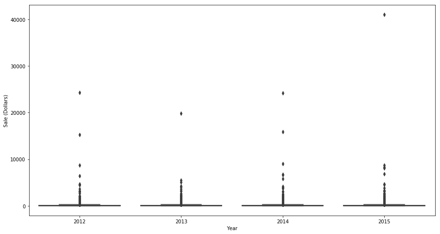

```python
plt.figure(figsize = (15, 8))
sns.boxplot(data = df, x = 'Year', y = 'Sale (Dollars)')
```

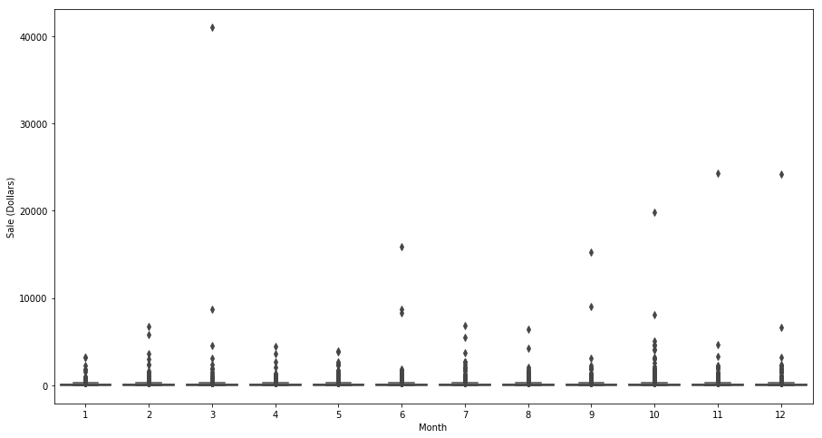

```python
plt.figure(figsize = (15, 8))
sns.boxplot(data = df, x = 'Month', y = 'Sale (Dollars)')
```

#### Seasonal Decomposition

```python
category = ['Bottle Volume (ml)', 'Bottles Sold','Sale (Dollars)', 'Volume Sold (Liters)', 'Volume Sold (Gallons)']
for x in category:
    result = seasonal_decompose(df[x], freq=365, model='additive')
    df1 = pd.concat([result.trend, result.seasonal, result.resid, result.observed], axis=1)
    df1.columns = ['trend', 'seasonal', 'residuals', 'observed']
    df1=df1.dropna()
    res=df1['residuals'].values
    obs=df1['observed'].values
    resmean=np.mean(np.abs(res))
    obsmean=np.mean(np.abs(obs))
    perc=resmean*100/obsmean
    print('**************' + x + '**************'+' \nRESMEAN:'+str(resmean)+', OBSMEAN:'+str(obsmean)+', PERC:'+str(perc)+'%')
```

```
**************Bottle Volume (ml)**************
RESMEAN:359.9875790540082, OBSMEAN:928.4297647722032, PERC:38.773808500456006%
**************Bottles Sold**************
RESMEAN:7.944208950376757, OBSMEAN:9.781735253420797, PERC:81.2147205435617%
**************Sale (Dollars)**************
RESMEAN:114.9560940944682, OBSMEAN:128.12556859529545, PERC:89.7214313698579%
**************Volume Sold (Liters)**************
RESMEAN:7.613172413823074, OBSMEAN:8.966419310203456, PERC:84.90761083590597%
**************Volume Sold (Gallons)**************
RESMEAN:2.0111821339952316, OBSMEAN:2.3688520473530468, PERC:84.90112906133268%
```

#### AutoCorrelation Analysis

The correlation is generally measured by the Pearson coefficient. The plot of autocorrelation is used to summarize the strength of the relationship with an observation with the prior time stamp.

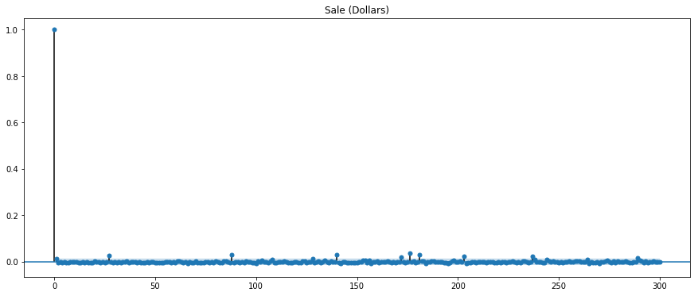

```python
with plt.rc_context():
    plt.rc("figure", figsize=(15,6))
    plot_acf(df['Sale (Dollars)'], lags=300, title='Sale (Dollars)')
```

The sales of the liquors has not shown much autocorrelation.

#### ARIMA Forecasting

ARIMA (Auto-Regressive Integrated Moving Average) forecasting models are most majorly used for forecasting univariate stationary time-series. Model uses the dependency relationship (correlation) between an observation and some number of previous observations in the past. Hyperparameters of one ARIMA model are:

- p(Lag order) : Number of observations in previous time steps included in the model for forecasting. Typically, it is equal to the lag at which partial autocorrelation cuts off the cone of the confidence interval.
- d(Differencing degree) : Number of times that the raw observations are differenced. If the data series is stationary, d=0. If not, it is d>1.
- q(Moving average order) : Size of the moving average window. It can take any value.

```python
bar = ProgressBar()
```

```python
def evaluate_arima_model(X, arima_order):
    train_size = int(len(X) * 0.9)
    train, test = X[0:train_size], X[train_size:]
    history = [x for x in train]
    predictions = []
    for t in bar(range(len(test))):
        model = ARIMA(history, order=arima_order)
        model_fit = model.fit(disp=0)
        y_pred = model_fit.forecast()[0]
        predictions.append(y_pred)
        history.append(test[t])
    error = mean_squared_error(test, predictions)
    #print(error)
    return error
```

```python
def evaluate_models(f, dataset, p_value, d_value, q_value):
    best_score, best_cfg = float("inf"), None
    order = (p_value,d_value,q_value)
    mse = evaluate_arima_model(dataset, order)
    if mse < best_score:
        best_score, best_cfg = mse, order
    print("=" * 50)
    print("ARIMA for M01AB with p = {}, d = {}, and q = {}. \nMSE Value= {}". format(p_value,d_value,q_value, best_score))
    #print(f+' - ARIMA for M01AB with MSE=%.2f' % (p_value,d_value,q_value, best_score))
```

```python
evaluate_models('Sale (Dollars)', df['Sale (Dollars)'].iloc[:200].values, 2, 1, 2)
```

```
100% (20 of 20) |########################| Elapsed Time: 0:00:08 Time:  0:00:08
```

```
==================================================
ARIMA for M01AB with p = 2, d = 1, and q = 2.
MSE Value= 18410.574115325933
```

To improve the MSE value hyperparameter tunning needs to be done. The different values of the p, q, and d will give us a better MSE value. Also, we have performed the ARIMA forecasting only on the Sale (Dollars) variable which is used to get the idea about the forecasting of the simple model. There are other versions of the ARIMA models like rolling forecasting with ARIMA, etc.

## Data Preprocessing and Feature Engineering for ML models

##### Dropping the unnecessary columns

As we can see in our data there are columns like Item Number, Zip Code, etc which does not make any sense or not important for the prediction of alcohol sales. So in the next cell we will drop such columns.

```python
df.drop(['Invoice/Item Number', 'Date', 'Store Number', 'Address', 'Zip Code', 'Store Location', 'County Number',
        'Category', 'Vendor Number', 'Item Number', 'Item Description', 'Volume Sold (Liters)', 'Volume Sold (Gallons)'],
        axis=1,
        inplace=True)
```

```python
df.columns
```

```
Index(['Store Name', 'City', 'County', 'Category Name', 'Vendor Name', 'Pack',
       'Bottle Volume (ml)', 'State Bottle Cost', 'State Bottle Retail',
       'Bottles Sold', 'Sale (Dollars)', 'Year', 'Month', 'Day'],
      dtype='object')
```

```python
# Replacing the dollar symbol in the 'State Bottle Cost' and 'State Bottle Retail' column by None.

df['State Bottle Cost'] = df['State Bottle Cost'].str.replace('$', '')
df['State Bottle Cost'] = df['State Bottle Cost'].astype('float')

df['State Bottle Retail'] = df['State Bottle Retail'].str.replace('$', '')
df['State Bottle Retail'] = df['State Bottle Retail'].astype('float')
```

### Correlations

- Finally, let's take a look at the relationships between numeric features and other numeric features.
- *Correlation* is a value between -1 and 1 that represents how closely values for two separate features move in unison.
- Positive correlation means that as one feature increases, the other increases; eg. a child's age and her height.
- Negative correlation means that as one feature increases, the other decreases; eg. hours spent studying and number of parties attended.
- Correlations near -1 or 1 indicate a strong relationship.
- Those closer to 0 indicate a weak relationship.
- 0 indicates no relationship.

```python
df.corr()
```

|  | Pack | Bottle Volume (ml) | State Bottle Cost | State Bottle Retail | Bottles Sold | Sale (Dollars) | Year | Month | Day |
| --- | --- | --- | --- | --- | --- | --- | --- | --- | --- |
| Pack | 1.000000 | -0.596063 | -0.354756 | -0.355879 | 0.095359 | -0.016820 | 0.001634 | -0.000959 | -0.004622 |
| Bottle Volume (ml) | -0.596063 | 1.000000 | 0.316837 | 0.318152 | -0.009592 | 0.053526 | 0.004622 | 0.002717 | 0.010150 |
| State Bottle Cost | -0.354756 | 0.316837 | 1.000000 | 0.999892 | -0.040045 | 0.144680 | 0.037840 | 0.022082 | 0.006008 |
| State Bottle Retail | -0.355879 | 0.318152 | 0.999892 | 1.000000 | -0.040171 | 0.144732 | 0.037106 | 0.022570 | 0.005948 |
| Bottles Sold | 0.095359 | -0.009592 | -0.040045 | -0.040171 | 1.000000 | 0.866007 | 0.004174 | 0.011754 | -0.001591 |
| Sale (Dollars) | -0.016820 | 0.053526 | 0.144680 | 0.144732 | 0.866007 | 1.000000 | 0.009648 | 0.014409 | -0.005534 |
| Year | 0.001634 | 0.004622 | 0.037840 | 0.037106 | 0.004174 | 0.009648 | 1.000000 | -0.046943 | -0.013226 |
| Month | -0.000959 | 0.002717 | 0.022082 | 0.022570 | 0.011754 | 0.014409 | -0.046943 | 1.000000 | -0.011821 |
| Day | -0.004622 | 0.010150 | 0.006008 | 0.005948 | -0.001591 | -0.005534 | -0.013226 | -0.011821 | 1.000000 |

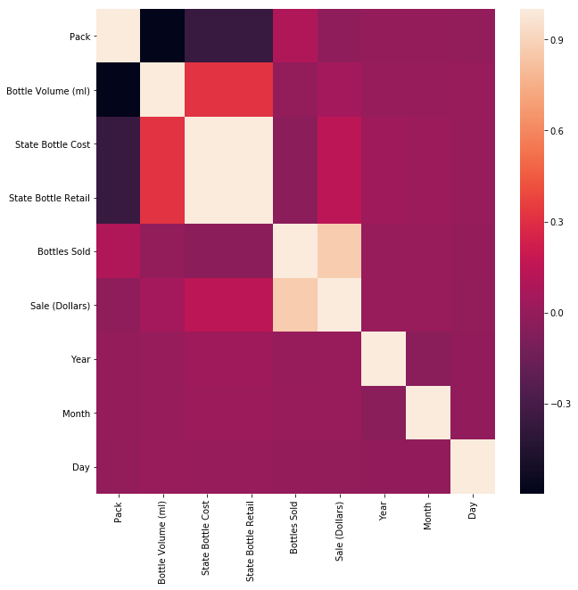

```python
plt.figure(figsize=(10,10))
sns.heatmap(df.corr())
```

#### Encoding categorical variables.

It is necessary to convert the categorical variable into numbers as ML models only takes the numbers as a input. So in our dataset the columns like Store Name, Category Name, Vendor Name are categorical.

```python
label_en1 = LabelEncoder()
df['Store Name'] = label_en1.fit_transform(df['Store Name'])

label_en2 = LabelEncoder()
df['Category Name'] = label_en2.fit_transform(df['Category Name'])

label_en3 = LabelEncoder()
df['Vendor Name'] = label_en3.fit_transform(df['Vendor Name'])

label_en4 = LabelEncoder()
df['County'] = label_en4.fit_transform(df['County'])

label_en5 = LabelEncoder()
df['City'] = label_en5.fit_transform(df['City'])
```

```python
df.dtypes
```

```
Store Name               int64
City                     int64
County                   int64
Category Name            int64
Vendor Name              int64
Pack                     int64
Bottle Volume (ml)       int64
State Bottle Cost      float64
State Bottle Retail    float64
Bottles Sold             int64
Sale (Dollars)         float64
Year                     int64
Month                    int64
Day                      int64
dtype: object
```

Now all the variables are converted into the numbers as per the requirement.

```python
df.reset_index(inplace = True)
df.head()
```

|  | index | Store Name | City | County | Category Name | Vendor Name | Pack | Bottle Volume (ml) | State Bottle Cost | State Bottle Retail | Bottles Sold | Sale (Dollars) | Year | Month | Day |
| --- | --- | --- | --- | --- | --- | --- | --- | --- | --- | --- | --- | --- | --- | --- | --- |
| 0 | 6 | 557 | 341 | 6 | 22 | 22 | 6 | 1500 | 11.62 | 17.43 | 6 | 104.58 | 2015 | 11 | 9 |
| 1 | 8 | 609 | 237 | 69 | 22 | 35 | 12 | 750 | 19.58 | 29.37 | 4 | 117.48 | 2015 | 11 | 30 |
| 2 | 13 | 1124 | 156 | 46 | 22 | 22 | 6 | 1500 | 11.62 | 17.43 | 1 | 17.43 | 2015 | 11 | 11 |
| 3 | 18 | 649 | 255 | 66 | 19 | 42 | 1 | 6000 | 99.00 | 148.50 | 1 | 148.50 | 2015 | 11 | 18 |
| 4 | 21 | 627 | 269 | 62 | 22 | 22 | 6 | 1500 | 11.62 | 17.43 | 6 | 104.58 | 2015 | 11 | 23 |

Separating target feature.

```python
y = df['Sale (Dollars)']
X = df.drop(['Sale (Dollars)', 'index'], axis = 1)
```

#### Data standardization

- In Data Standardization we perform zero mean centring and unit scaling; i.e. we make the mean of all the features as zero and the standard deviation as 1.
- Thus we use **mean** and **standard deviation** of each feature.
- It is very important to save the **mean** and **standard deviation** for each of the feature from the **training set**, because we use the same mean and standard deviation in the test set.

```python
a = StandardScaler()
X = a.fit_transform(X)
```

```python
X.mean()
```

```
-2.9119490494047272e-15
```

```python
X.std()
```

```
1.0
```

#### Train and validation split

As we have to developed the model to predict the sales of alcohol so we will build the regression model and accordingly also do the splitting of the data.

```python
# Split X and y into train and test sets: 80-20
X_train, X_test, y_train, y_test = train_test_split(X, y, test_size=0.2, random_state=1234)
```

```python
print(X_train.shape, X_test.shape, y_train.shape, y_test.shape)
```

```
(15901, 13) (3976, 13) (15901,) (3976,)
```

## Machine Learning Models

#### 1. Ridge Regression

```python
ridge1 = Ridge()
ridge1.fit(X_train, y_train)
```

```
Ridge(alpha=1.0, copy_X=True, fit_intercept=True, max_iter=None,
   normalize=False, random_state=None, solver='auto', tol=0.001)
```

```python
## Predict Test results
y_pred = ridge1.predict(X_test)


print("Validation Results for Ridge Regression:")
print("*******************************")
print("Root mean squared error: ", sqrt(mse(y_test, y_pred)))
print("R-squared: ", r2_score(y_test, y_pred))
print("Mean Absolute Error: ", mae(y_test, y_pred))
```

```
Validation Results for Ridge Regression:
Root mean squared error:  210.92303158045775
R-squared:  0.796983613132464
Mean Absolute Error:  64.2534629528685
```

#### Feature Importance

```python
## Building the model again with the best hyperparameters
model = Ridge(alpha=1)
model.fit(X_train, y_train)
```

```
Ridge(alpha=1, copy_X=True, fit_intercept=True, max_iter=None,
   normalize=False, random_state=None, solver='auto', tol=0.001)
```

```python
lst = ['Store Name', 'City', 'County', 'Category Name', 'Vendor Name',
       'Pack', 'Bottle Volume (ml)', 'State Bottle Cost',
       'State Bottle Retail', 'Bottles Sold', 'Year',
       'Month', 'Day']
```

```python
indices = np.argsort(-abs(model.coef_))
print("The features in order of importance are:")
print(50*'-')
#print(indices)
for i in range(len(indices)):
    print(lst[indices[i]])
```

```
The features in order of importance are:
--------------------------------------------------
Bottles Sold
State Bottle Retail
State Bottle Cost
Pack
Bottle Volume (ml)
Category Name
Vendor Name
City
County
Day
Store Name
Month
Year
```

#### 2. Random Forest

```python
random1 = RandomForestRegressor()
random1.fit(X_train, y_train)
```

```
RandomForestRegressor(bootstrap=True, criterion='mse', max_depth=None,
           max_features='auto', max_leaf_nodes=None,
           min_impurity_decrease=0.0, min_impurity_split=None,
           min_samples_leaf=1, min_samples_split=2,
           min_weight_fraction_leaf=0.0, n_estimators=10, n_jobs=1,
           oob_score=False, random_state=None, verbose=0, warm_start=False)
```

```python
## Predict Test results
y_pred = random1.predict(X_test)


print("Validation Results for Random Forest Regression:")
print("*******************************")
print("Root mean squared error: ", sqrt(mse(y_test, y_pred)))
print("R-squared: ", r2_score(y_test, y_pred))
print("Mean Absolute Error: ", mae(y_test, y_pred))
```

```
Validation Results for Random Forest Regression:
Root mean squared error:  160.59002917763414
R-squared:  0.8823152365553526
Mean Absolute Error:  6.258770372233405
```

#### Feature Importance

```python
## Building the model again with the best hyperparameters
model = RandomForestRegressor()
model.fit(X_train, y_train)
```

```
RandomForestRegressor(bootstrap=True, criterion='mse', max_depth=None,
           max_features='auto', max_leaf_nodes=None,
           min_impurity_decrease=0.0, min_impurity_split=None,
           min_samples_leaf=1, min_samples_split=2,
           min_weight_fraction_leaf=0.0, n_estimators=10, n_jobs=1,
           oob_score=False, random_state=None, verbose=0, warm_start=False)
```

```python
indices = np.argsort(-abs(model.feature_importances_))
print("The features in order of importance are:")
print(50*'-')
#print(indices)
for i in range(len(indices)):
    print(lst[indices[i]])
```

```
The features in order of importance are:
--------------------------------------------------
Bottles Sold
State Bottle Retail
State Bottle Cost
Store Name
Pack
Day
Month
Category Name
County
Vendor Name
City
Year
Bottle Volume (ml)
```

#### 3. XGBoost

```python
xgb1 = XGBRegressor(n_estimators=1000)
xgb1.fit(X_train, y_train)
```

```
XGBRegressor(base_score=0.5, booster='gbtree', colsample_bylevel=1,
       colsample_bytree=1, gamma=0, learning_rate=0.1, max_delta_step=0,
       max_depth=3, min_child_weight=1, missing=None, n_estimators=1000,
       n_jobs=1, nthread=None, objective='reg:linear', random_state=0,
       reg_alpha=0, reg_lambda=1, scale_pos_weight=1, seed=None,
       silent=True, subsample=1)
```

```python
## Predict Test results
y_pred = xgb1.predict(X_test)


print("Validation Results for Xgboost Regression:")
print("*******************************")
print("Root mean squared error: ", sqrt(mse(y_test, y_pred)))
print("R-squared: ", r2_score(y_test, y_pred))
print("Mean Absolute Error: ", mae(y_test, y_pred))
```

```
Validation Results for Xgboost Regression:
Root mean squared error:  95.02449732515866
R-squared:  0.9587945893672334
Mean Absolute Error:  5.947725478348358
```

#### Feature Importance

```python
## Building the model again with the best hyperparameters
model = XGBRegressor(n_estimators=1000)
model.fit(X_train, y_train)
```

```
XGBRegressor(base_score=0.5, booster='gbtree', colsample_bylevel=1,
       colsample_bytree=1, gamma=0, learning_rate=0.1, max_delta_step=0,
       max_depth=3, min_child_weight=1, missing=None, n_estimators=1000,
       n_jobs=1, nthread=None, objective='reg:linear', random_state=0,
       reg_alpha=0, reg_lambda=1, scale_pos_weight=1, seed=None,
       silent=True, subsample=1)
```

```python
indices = np.argsort(-abs(model.feature_importances_))
print("The features in order of importance are:")
print(50*'-')
#print(indices)
for i in range(len(indices)):
    print(lst[indices[i]])
```

```
The features in order of importance are:
--------------------------------------------------
Bottles Sold
State Bottle Cost
State Bottle Retail
Store Name
Vendor Name
Category Name
Day
City
County
Bottle Volume (ml)
Pack
Month
Year
```

From the preformance of the 3 models we can say that the XGBoost has performed very well. So saving the model to the disk.

```python
joblib.dump(xgb1, 'model.pkl')
```

```
['model.pkl']
```

#### 4. Deep Neural Network (MLP for Time Series Forecasting).

MLP for Time Series Forecasting First we will use a Multilayer Perceptron model or MLP model, here our model will have input features equal to the window size. The thing with MLP models is that the model don't take the input as sequenced data, so for the model, it is just receiving inputs and don't treat them as sequenced data, that may be a problem since the model won't see the data with the sequence patter that it has.

Input shape [samples, timesteps].

```python
epochs = 10
batch = 512
lr = 0.001
adam = optimizers.Adam(lr)
```

```python
model_mlp = Sequential()
model_mlp.add(Dense(256, activation='relu', input_dim=X_train.shape[1]))
model_mlp.add(Dense(256, activation='relu'))
model_mlp.add(Dense(64, activation='relu'))
model_mlp.add(Dense(32, activation='relu'))
model_mlp.add(Dense(16, activation='relu'))
model_mlp.add(Dense(1))
model_mlp.compile(loss='mse', optimizer=adam)
model_mlp.summary()
```

```
_________________________________________________________________
Layer (type)                 Output Shape              Param #
=================================================================
dense_110 (Dense)            (None, 256)               3584
_________________________________________________________________
dense_111 (Dense)            (None, 256)               65792
_________________________________________________________________
dense_112 (Dense)            (None, 64)                16448
_________________________________________________________________
dense_113 (Dense)            (None, 32)                2080
_________________________________________________________________
dense_114 (Dense)            (None, 16)                528
_________________________________________________________________
dense_115 (Dense)            (None, 1)                 17
=================================================================
Total params: 88,449
Trainable params: 88,449
Non-trainable params: 0
_________________________________________________________________
```

```python
mlp_history = model_mlp.fit(X_train, y_train, validation_data=(X_test, y_test), epochs=epochs, verbose=2)
```

```
Train on 15901 samples, validate on 3976 samples
 - 4s - loss: 119897.0782 - val_loss: 36398.2192
 - 2s - loss: 67188.3705 - val_loss: 65402.5454
 - 2s - loss: 69384.8391 - val_loss: 33760.6475
 - 2s - loss: 61939.9016 - val_loss: 86635.8591
 - 2s - loss: 49310.8842 - val_loss: 100864.6948
 - 2s - loss: 53243.2216 - val_loss: 46231.4297
 - 2s - loss: 71441.7387 - val_loss: 23939.7730
 - 2s - loss: 59598.8829 - val_loss: 21693.6500
 - 2s - loss: 36034.9250 - val_loss: 23594.7648
 - 2s - loss: 21111.6273 - val_loss: 56468.6458
```

As we can see from above traning process that the models is overfitting due to the less amount of data.

```python
## Predict Test results
y_pred = model_mlp.predict(X_test)


print("Validation Results for DNN model:")
print("*******************************")
print("Root mean squared error: ", sqrt(mse(y_test, y_pred)))
print("R-squared: ", r2_score(y_test, y_pred))
print("Mean Absolute Error: ", mae(y_test, y_pred))
```

[output not shown]